# R Lab: Basic Operations - sort(), rank(), and order()

Laiza Joy Berganio

2026-11-10

## **Part A — Creating Data Frames**

**Note**: Do not forget the codes before answering each questions. Codes must also be visible.

**Question #1**

1. Create a vector.

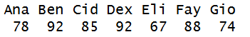

Student Scores

```r
scores <- c(Ana = 78, Ben = 92, Cid = 85, Dex = 92, Eli = 67, Fay = 88, Gio = 74)
scores
```

```
## Ana Ben Cid Dex Eli Fay Gio
##  78  92  85  92  67  88  74
```

2. Sort the scores in ascending order and descending order. What is the output?

```r
sort(scores)
```

```
## Eli Gio Ana Cid Fay Ben Dex
##  67  74  78  85  88  92  92
```

```r
sort(scores, decreasing = TRUE)
```

```
## Ben Dex Fay Cid Ana Gio Eli
##  92  92  88  85  78  74  67
```

3. Print your sorted result from sort-ascending. Check whether the # names (“Ana”, “Ben”, …) stayed attached to their correct values.

```r
sorted_scores <- sort(scores)
sorted_scores
```

```
## Eli Gio Ana Cid Fay Ben Dex
##  67  74  78  85  88  92  92
```

4. Create another vectors:

`subjects <- c("Science", "Math", "English", "Filipino", "PE")` `incomplete <- c(85, NA, 90, 70, NA, 95)`

```r
subjects <- c("Science", "Math", "English", "Filipino", "PE")
incomplete <- c(85, NA, 90, 70, NA, 95)
```

5. Sort subjects alphabetically using `sort()`

```r
sort(subjects)
```

```
## [1] "English"  "Filipino" "Math"     "PE"       "Science"
```

6. Sort incomplete using sort(). Observe what happens to the NA

```r
# values by default.
# TODO: Now sort it again using na.last = TRUE so the NAs appear at the end

sort(incomplete)
```

```
## [1] 70 85 90 95
```

```r
sort(incomplete, na.last = TRUE)
```

```
## [1] 70 85 90 95 NA NA
```

**Question #2:**

- When you sorted `scores`, did the names stay correctly attached to their original values?
- Explain why this matters: if you were sorting exam scores to find the top performer, what would go wrong if the names did NOT follow their values?

Yes. The names of a vector are labels attached to their values, so when `sort()` arranges the values, the names move along with the values. If we were to sort exam scores to find the top performer, `names` that do not follow with their values would cause a mismatch. Values with incorrect names would lead to incorrect results. We could pick the wrong student because of this.

**Question #3:**

- By default, `sort()` silently removes `NA` values instead of showing them or throwing an error.
- Why might this default behavior be dangerous if you were reporting “the lowest score” in a dataset with missing data, without first checking for `NA` values?.

`sort()` removes `NA` values without any warning. If we report the lowest score from the sorted result, we are only looking at the students who have scores. A student with a missing score, who might be the lowest, is left out, so the report looks complete but isn’t. This is why we should check for `NA` first, for example with `sum(is.na(x))`.

**Question #4:**

- Use `order(scores)` and print the result. Compare this output to the `sort(scores)` output. What is the difference?

```r
order(scores)
```

```
## [1] 5 7 1 3 6 2 4
```

1. Use the result of order(scores) to index scores itself: # Compare this to sort(scores) – they should produce the same values.

```r
scores[order(scores)]
```

```
## Eli Gio Ana Cid Fay Ben Dex
##  67  74  78  85  88  92  92
```

```r
sort(scores)
```

```
## Eli Gio Ana Cid Fay Ben Dex
##  67  74  78  85  88  92  92
```

- Do they have the same values? Explain briefly.

The `order(scores)` gives the positions of the values, while `sort(scores)` gives the sorted values themselves. Yes, `scores[order(scores)]` and `sort(scores)` have the same values, because the positions from `order()` put the scores in ascending order.

**Question #5:**

- Create a dataframe from these vectors `name = c("Ana", "Ben", "Cid", "Dex", "Eli", "Fay", "Gio")` `score = c(78, 92, 85, 92, 67, 88, 74)` `section = c("A", "B", "A", "B", "A", "B", "A")`

  What is the output?

```r
students <- data.frame(
  name = c("Ana", "Ben", "Cid", "Dex", "Eli", "Fay", "Gio"),
  score = c(78, 92, 85, 92, 67, 88, 74),
  section = c("A", "B", "A", "B", "A", "B", "A")
)
students
```

```
##   name score section
## 1  Ana    78       A
## 2  Ben    92       B
## 3  Cid    85       A
## 4  Dex    92       B
## 5  Eli    67       A
## 6  Fay    88       B
## 7  Gio    74       A
```

1. Reorder the ENTIRE students data frame by score `using students[order(students$score), ]`
- What is the output?

```r
students[order(students$score), ]
```

```
##   name score section
## 5  Eli    67       A
## 7  Gio    74       A
## 1  Ana    78       A
## 3  Cid    85       A
## 6  Fay    88       B
## 2  Ben    92       B
## 4  Dex    92       B
```

The data frame is now arranged by score in ascending order.

2. Reorder students by score in DESCENDING order.

```r
students[order(students$score, decreasing = TRUE), ]
```

```
##   name score section
## 2  Ben    92       B
## 4  Dex    92       B
## 6  Fay    88       B
## 3  Cid    85       A
## 1  Ana    78       A
## 7  Gio    74       A
## 5  Eli    67       A
```

**Question #6:**

`sort(scores)` and `scores[order(scores)]` produce the same final values, but they work completely differently under the hood.

- In your own words, explain what `order(scores)` actually returns (look at the raw numbers it gives you), and why that output is useless on its own unless you use it to index something.

`order(scores)` returns the position of the values `5 7 1 3 6 2 4`. It says the smallest score is in position 5, the next smallest is in position 7, and so on. On its own, it’s only a list of positions and it tells us nothing about the data. `order()` becomes useful when we use it as an index, like scores[order(scores)], R rearranges the data in that order.

**Question #7:**

- Explain why `sort()` alone could NOT have been used to reorder the whole `students` data frame by score (try to imagine running `sort(students)` and think about what “sorting a table” would even mean).
- Why is `order()` the correct tool whenever you need to keep multiple related columns lined up with each other?

`sort()` only works on a single vector and returns only the sorted values. If we sort one column of a table on its own, the other columns wouldn’t move with it, then each name and section would no longer match its score. `order()` is the correct tool because it returns row positions, so `students[order(students$score), ]` moves whole rows together and keeps every column lined up with the others.

**Question #8:**

```r
# TODO: Use rank(scores) and print the result.
# Print scores, then rank(scores), side by side (e.g., using # cbind(scores, rank(scores))) so you can see which score got which rank

rank(scores)
```

```
## Ana Ben Cid Dex Eli Fay Gio
## 3.0 6.5 4.0 6.5 1.0 5.0 2.0
```

```r
cbind(scores, rank(scores))
```

```
##     scores
## Ana     78 3.0
## Ben     92 6.5
## Cid     85 4.0
## Dex     92 6.5
## Eli     67 1.0
## Fay     88 5.0
## Gio     74 2.0
```

1. Ranking the output for Ben and Dex

```r
# TODO: Look at the rank() output for Ben and Dex.

rank(scores)
```

```
## Ana Ben Cid Dex Eli Fay Gio
## 3.0 6.5 4.0 6.5 1.0 5.0 2.0
```

- What rank did each of them receive?

Ben received a rank of 6.5, and Dex also received a rank of 6.5.

2. Ben and Dex both scored 92, the highest score in the class, but under the default `rank()` they did NOT both simply get rank “1” or rank “7” as a whole number. Explain exactly what value they received by default and why R computes it that way for tied values.

Ben and Dex both received a rank of 6.5. They tied for the two scores. Those scores would normally be ranked 6 and 7. R assigns tied values the average of the ranks they share so (6 + 7) / 2 equals 6.5. That method keeps the ranks adding up. Neither Ben nor Dex ends up with a position better than the other.

**Question #8:**

1. Create a dataframe.

`sales <- data.frame(` `employee = c("Rey", "Sam", "Tin", "Uma", "Val"),` `units_sold = c(120, 145, 145, 98, 130)`

```r
sales <- data.frame(
  employee = c("Rey", "Sam", "Tin", "Uma", "Val"),
  units_sold = c(120, 145, 145, 98, 130)
)
```

- Add a column sales$rank that ranks employees by units_sold, with the TOP seller receiving rank 1.

```r
sales$rank <- rank(-sales$units_sold)
sales
```

```
##   employee units_sold rank
## 1      Rey        120  4.0
## 2      Sam        145  1.5
## 3      Tin        145  1.5
## 4      Uma         98  5.0
## 5      Val        130  3.0
```

2. Reorder the entire sales data frame using order() so it is displayed from HIGHEST units_sold to LOWEST.

```r
sales[order(sales$units_sold, decreasing = TRUE), ]
```

```
##   employee units_sold rank
## 2      Sam        145  1.5
## 3      Tin        145  1.5
## 5      Val        130  3.0
## 1      Rey        120  4.0
## 4      Uma         98  5.0
```

**Question #9:**

- In this challenge, you used `rank()` to determine standing and `order()` to determine display order.
- Could you have used `order()` alone to solve the entire problem (both awarding ranks AND reordering the table)?
- Explain what `order()` is missing that `rank()` provides, using your own words rather than repeating the definitions

No, `order()` alone couldn’t do both jobs. `order()` only gives the positions needed to arrange the data from smallest to largest, so it solves the display order. It doesn’t give each employee a standing, and it doesn’t say what happens when two people tie. `rank()` gives each value its standing, so Sam and Tin both show 1.5 instead of one of them higher than the other. `order()` tells us where to put each row, and `rank()` tells us what place each one finished in.